# ebame

2022-10-24

In this tutorial we’ll perform some further analyses and visualizations of our ancient plague mapping data. First, we load some packages and set up some helper data needed for the analyses

```r
## libraries
library(tidyverse)
library(ggrepel)
library(viridis)
library(Rsamtools)
## helpers
refInfo <- tibble(assemblyId = c("GCF_000009065.1_ASM906v1", "GCF_000834295.1_ASM83429v1", "GCF_009730055.1_ASM973005v1"),
                  species = c("Y_pestis", "Y_pseudotuberculosis", "Y_intermedia"))
```

### Genome-wide coverage summaries

First we will examine the genomic coverage distributions across the different reference genomes used in the mapping, using the previously computed coverage histograms. We read in and process the histogram data

```r
## coverage histogram files
f <- list.files(path = "results",
                pattern = "genomecov",
                full.names = TRUE)

## loop over files and read in data
d <- map_dfr(f, ~{

    r1 <- read_tsv(.x,
                   col_type = "ciddd",
                   col_names = c("contigId", "dp", "count", "l", "p"))

    s <- .x %>%
        strsplit("\\.") %>%
        map_chr(function(x) paste(x[2:3], collapse = "."))

    r1 %>%
        mutate(assemblyId = s) %>%
        left_join(refInfo)
})
```

Let’s have a look at the overall read depth distributions for each reference genome

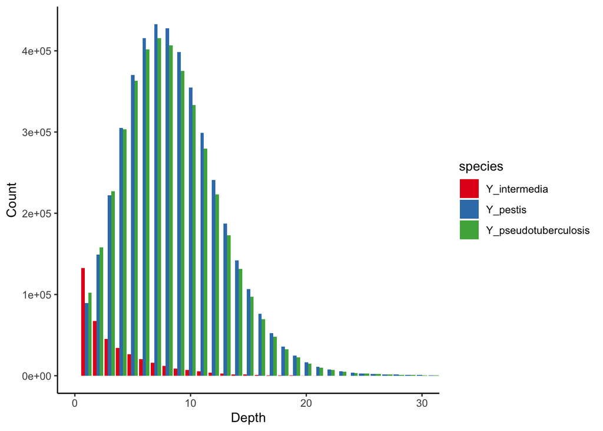

```r
## plot genome-wide histograms
p <- d %>%
    filter(contigId == "genome",
           dp > 0) %>%
    ggplot(aes(x = dp,
                    y = count))

p +
    geom_col(aes(fill = species),
             position = position_dodge()) +
    coord_cartesian(xlim = c(0, 30)) +
    xlab("Depth") +
    ylab("Count") +
    scale_fill_brewer(palette = "Set1") +
    theme_classic()
```

We can use the histograms to calculate coverage summaries such as average read depth, and expected / observed breadth of coverage

```r
## calculate mean coverage, breadth of coverage and expected vs observed
d1 <- d %>%
    group_by(assemblyId, species, contigId) %>%
    summarise(contigL = l[1],
              dpAvg = sum(dp * count) / contigL,
              coverageP = 1 - p[1],
              coveragePExp = 1 - exp(-dpAvg),
              coveragePRatio = coverageP / coveragePExp,
              .groups = "drop")
```

Let’s plot the average read depth for each contig

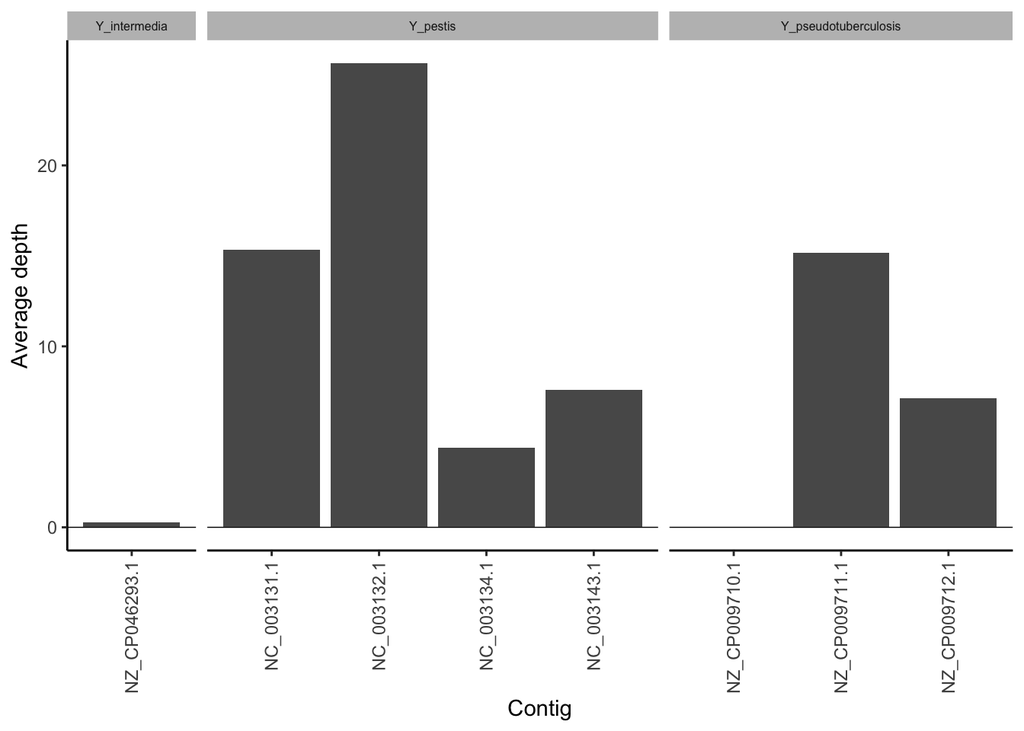

```r
## plot average coverage for contigs
p <- d1 %>%
    filter(contigId != "genome") %>%
    ggplot(aes(x = contigId,
               y = dpAvg))
p +
    geom_hline(yintercept = 0,
               size = 0.25) +
    geom_col() +
    facet_grid(. ~ species,
               scales = "free",
               space = "free_x") +
    xlab("Contig") +
    ylab("Average depth") +
    theme_classic() +
    theme(axis.text.x = element_text(angle = 90,
                                     hjust = 1,
                                     vjust = 0.5),
          strip.background = element_rect(fill = "grey",
                                          color = NA),
          strip.text.x = element_text(size = 6))
```

We can compare how our observed breadth of coverage compares to the expected one, given the average read depth

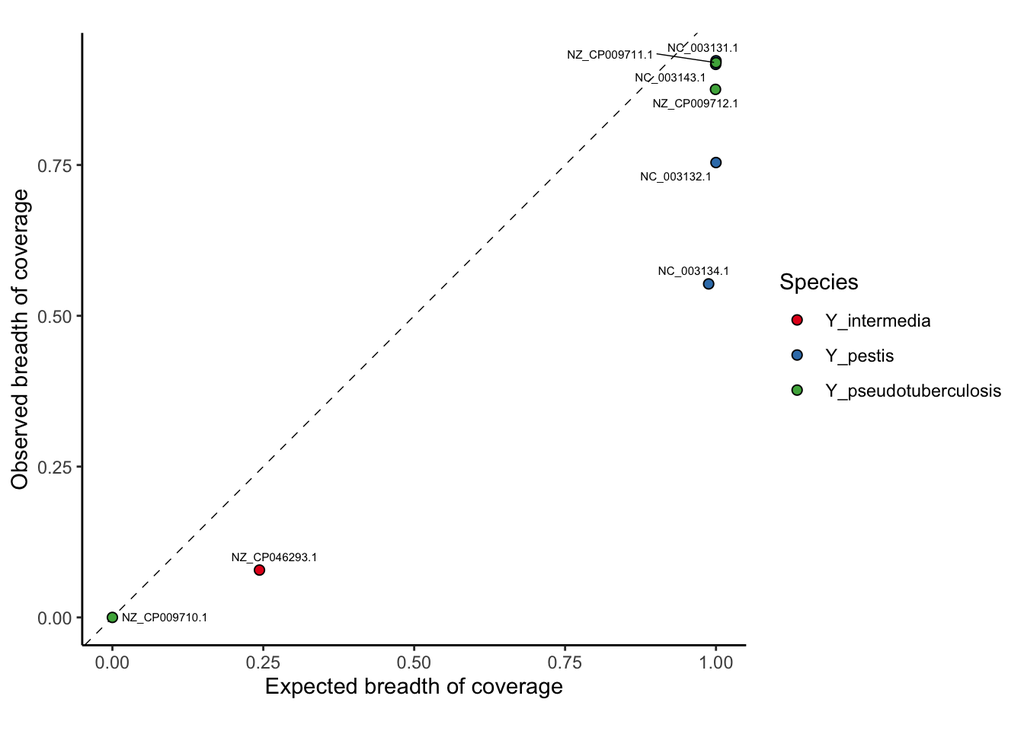

```r
## plot expected vs observed coverage for each contig
p <- d1 %>%
    filter(contigId != "genome") %>%
    ggplot(aes(x = coveragePExp,
               y = coverageP))
p +
    geom_abline(intercept = 0,
                slope = 1,
                linetype = "dashed",
                size = 0.25) +
    geom_point(aes(fill = species),
               color = "black",
               shape = 21,
               size = 2) +
    geom_text_repel(aes(label = contigId),
                    size = 2,
                    segment.size = 0.25) +
    xlab("Expected breadth of coverage") +
    ylab("Observed breadth of coverage") +
    scale_fill_brewer(name = "Species",
                      palette = "Set1") +
    coord_equal() +
    theme_classic()
```

### Edit distance distributions

We have seen that coverage distributions for *Y pestis* and *Y pseudotuberculosis* are very similar. Let’s find out which of the reference genomes our sequencing reads are more similar to. We can examine the read edit distances by processing the `MD` tags of the mapped reads

```r
## read MD tags from BAM files
f <- list.files(path = "results",
                pattern = "rmdup.bam",
                full.names = TRUE)

p1 <- ScanBamParam(tag=c("NM"),
                   mapqFilter = 20)

d <- map_dfr(f, ~{

    r1 <- scanBam(.x,
                  param=p1) %>%
        unlist() %>%
        as.integer()

    s <- .x %>%
        strsplit("\\.") %>%
        map_chr(function(x) paste(x[2:3], collapse = "."))

    r <- tibble(assemblyId = s,
                nm = r1)
    r
})
```

We summarize and plot the distributions for each of the three reference genome mappings

```r
## calculate edit distance distributions
d1 <- d %>%
    count(assemblyId, nm) %>%
    group_by(assemblyId) %>%
    mutate(pNm = n / sum(n)) %>%
    left_join(refInfo)
```

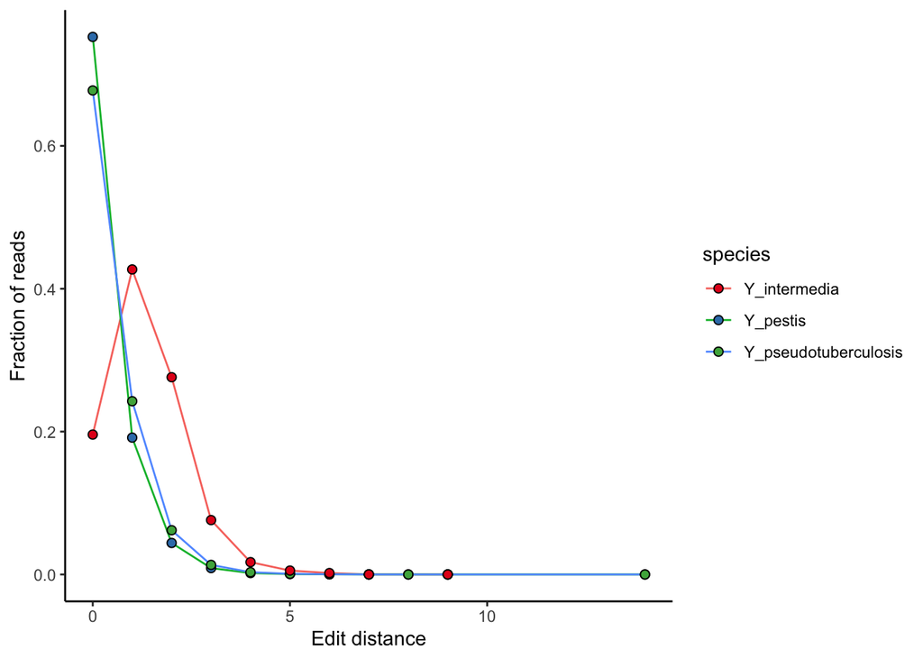

```r
## plot
p <- ggplot(d1, aes(x = nm,
                    y = pNm))

p +
    geom_line(aes(color = species)) +
    geom_point(aes(fill = species),
               shape = 21,
               size = 2) +
    xlab("Edit distance") +
    ylab("Fraction of reads") +
    scale_fill_brewer(palette = "Set1") +
    theme_classic()
```

### Gene coverage

Our contig-level analysis for *Y pestis* has shown that the breadth of coverage for the virulence plasmid pMT1 (`NC_003134.1`) is lower than expected. Let’s investigate the coverage for genes encoded on pMT1 in more detail. We read and process the pre-computed coverage histograms stratified by genomic features

```r
## read gene coverage for Y pestis
d <- read_tsv("results/RISE505.GCF_000009065.1_ASM906v1.mapped.sort.rmdup.genes.coverage.tsv",
              col_names = c("contigId", "featureSource", "featureType", "posStart", "posEnd", "score", "strand", "phase", "attributes", "dp", "count", "l", "p"))
## get coverage summaries per gene
d1 <- d %>%
    filter(contigId != "all",
           featureType == "CDS") %>%
    group_by(contigId, posStart, posEnd, attributes) %>%
    summarise(dpAvg = sum(dp * count) / l[1],
              coverageP = 1 - p[1],
              .groups = "drop") %>%
    mutate(parent = gsub(".*Parent=(.*?);.*", "\\1", attributes),
           product = gsub(".*product=(.*?);.*", "\\1", attributes),
           label = paste(parent, product, sep = ";"))
```

We can now plot the breadth of coverage for each gene encoded on pMT1 (`NC_003134.1`)

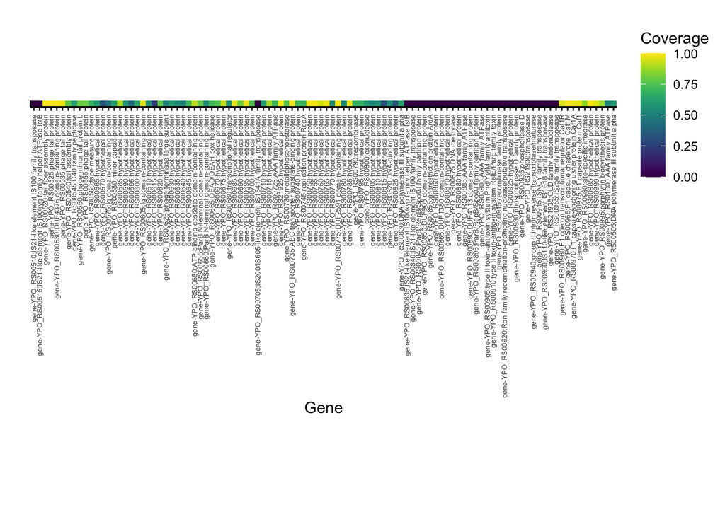

```r
## plot gene coverage in pMT1 plasmid
p <- d1 %>%
    filter(contigId == "NC_003134.1") %>%
    mutate(label = factor(label, levels = unique(label))) %>%
    ggplot(aes(x = label,
               y = 1))

p +
    geom_tile(aes(fill = coverageP)) +
    scale_fill_viridis(name = "Coverage",
                       limits = c(0, 1)) +
    coord_equal() +
    xlab("Gene") +
    ylab("") +
    theme_classic() +
    theme(axis.text.x = element_text(angle = 90,
                                     hjust = 1,
                                     vjust = 0.5,
                                     size = 5),
          axis.text.y = element_blank(),
          axis.ticks.y = element_blank())
```

We observe that multiple genes covering a part of the plasmid show no covereage. Among those is the *ymt* (Yersinia murine toxine) gene, which is an important virulence factor in plague transmission (label `YPO_RS00935;phospholipase D` in the plot).